# Presentación R Baselines

Joaquin Gueler

2024-01-02

## R baseline

En esta presetación realizaré el ejercico propuesto analizando el dataframe Babynames que contiene, agrupado por nombre y sexo, la cantidad de nacimientos en Estado Unidos por año desde 1880 hasta 2017.

### Pequeño analisis sobre el dataframte

```r
babynames %>% head(10)
```

```
## # A tibble: 10 × 5
##     year sex   name          n   prop
##    <dbl> <chr> <chr>     <dbl>  <dbl>
##  1  1880 F     Mary       7065 0.0724
##  2  1880 F     Anna       2604 0.0267
##  3  1880 F     Emma       2003 0.0205
##  4  1880 F     Elizabeth  1939 0.0199
##  5  1880 F     Minnie     1746 0.0179
##  6  1880 F     Margaret   1578 0.0162
##  7  1880 F     Ida        1472 0.0151
##  8  1880 F     Alice      1414 0.0145
##  9  1880 F     Bertha     1320 0.0135
## 10  1880 F     Sarah      1288 0.0132
```

Control valores Na

```r
# control de Na
babynames %>% summarise_all(~ sum(is.na(.)))
```

```
## # A tibble: 1 × 5
##    year   sex  name     n  prop
##   <int> <int> <int> <int> <int>
## 1     0     0     0     0     0
```

Analisis columnas

```r
babynames %>%  summary(.)
```

```
##       year          sex                name                 n
##  Min.   :1880   Length:1924665     Length:1924665     Min.   :    5.0
##  1st Qu.:1951   Class :character   Class :character   1st Qu.:    7.0
##  Median :1985   Mode  :character   Mode  :character   Median :   12.0
##  Mean   :1975                                         Mean   :  180.9
##  3rd Qu.:2003                                         3rd Qu.:   32.0
##  Max.   :2017                                         Max.   :99686.0
##       prop
##  Min.   :2.260e-06
##  1st Qu.:3.870e-06
##  Median :7.300e-06
##  Mean   :1.363e-04
##  3rd Qu.:2.288e-05
##  Max.   :8.155e-02
```

Analisis de columnas tipo texto

```r
babynames %>%
  select_if(is.character) %>%
  summarise_all(list(
    unique_count = ~ n_distinct(.),
    min_length =   ~ min(nchar(.)),
    max_length =   ~ max(nchar(.)),
    avg_length =   ~ mean(nchar(.), na.rm = TRUE)
  ))  %>%
  gather(Nombres_Columna, Valor, everything()) %>%
  separate(Nombres_Columna, into = c("columna", "Estadística"), sep = "_", extra = "merge") %>%
  spread(columna, Valor)
```

```
## # A tibble: 4 × 3
##   Estadística      name   sex
##   <chr>           <dbl> <dbl>
## 1 avg_length       6.17     1
## 2 max_length      15        1
## 3 min_length       2        1
## 4 unique_count 97310        2
```

### Preguntas

Ya habiendo realizado un sucinto analisis sobre las caracteristicas principales del dataframe babynames, me propongo contestar las siguentes preguntas:

1. Sin distinguir por sexo, cúal es el nombre con mayor peso proporcional al comienzo (1880) y al final (2017) de la serie ? Cómo evolucionaron a lo largo del tiempo?
2. Cómo evoluionó a lo largo del tiempo la cantidad de nombres únicos utilizados por año?
3. Si agrupamos los nombres en relación a si son utilizados de manera exclusiva por un sexo o no, cúal es el peso proporcional de los nombres mixtos? cómo es su evolución a lo largo del tiempo?

Para contestar las preguntas voy a crear una tabla temporal en sql server y desde ahí voy producir las agregaciones necesarias.

```r
# Contrucción de tabla temporal


table_name <- '#Baby_Names'

table_estruc <- '(year int,
                  sex  char(1),
                  name varchar(15),
                  n int,
                  prop float)'


con <- dbConnect(odbc::odbc(), "SQL Server ")

# Crear la tabla temporal en SQL Server
dbExecute(con, paste('create table',table_name,table_estruc),immediate = TRUE)

# Insertar datos en la tabla temporal desde babynames
dbWriteTable(con, table_name, value = babynames, temporary = TRUE, overwrite = TRUE)
```

```r
#Query de prueba
dbGetQuery(con, paste("select top 10 * from ",table_name,"order by n desc"))
```

```
##    year sex    name     n       prop
## 1  1947   F   Linda 99686 0.05483812
## 2  1948   F   Linda 96209 0.05521079
## 3  1947   M   James 94756 0.05101589
## 4  1957   M Michael 92695 0.04237565
## 5  1947   M  Robert 91642 0.04933934
## 6  1949   F   Linda 91016 0.05184643
## 7  1956   M Michael 90620 0.04225546
## 8  1958   M Michael 90520 0.04204290
## 9  1948   M   James 88588 0.04969695
## 10 1954   M Michael 88514 0.04279319
```

### Pregunta 1

```r
respuesta_1 <-
            dbGetQuery(con,

                          " with total_anio as (


                                  select
                                    ba.year
                                   ,ba.name
                                   ,ba.n
                                   ,ba.n * 1.0 / t1.total as prop
                                  from (select year,name, sum(n) as n from #Baby_Names group by year,name) as ba
                                  left join (select year,sum(n) as total from #Baby_Names group by year) as t1
                                  on t1.year = ba.year

                                 ),
                                nombre_mas_popular_extremos_ventana as (

                                    select
                                      t1.*
                                    from (select top 1 * from total_anio order by year asc, prop desc) as t1
                                   union
                                    select
                                      t2.*
                                    from (select top 1 * from total_anio order by year desc, prop desc) as t2
                                 )

                                 select
                                    t.year
                                   ,t.name
                                   ,t.n
                                   ,t.prop
                                 from total_anio as t
                                 inner join nombre_mas_popular_extremos_ventana as n
                                 on n.name = t.name; "

                       )
```

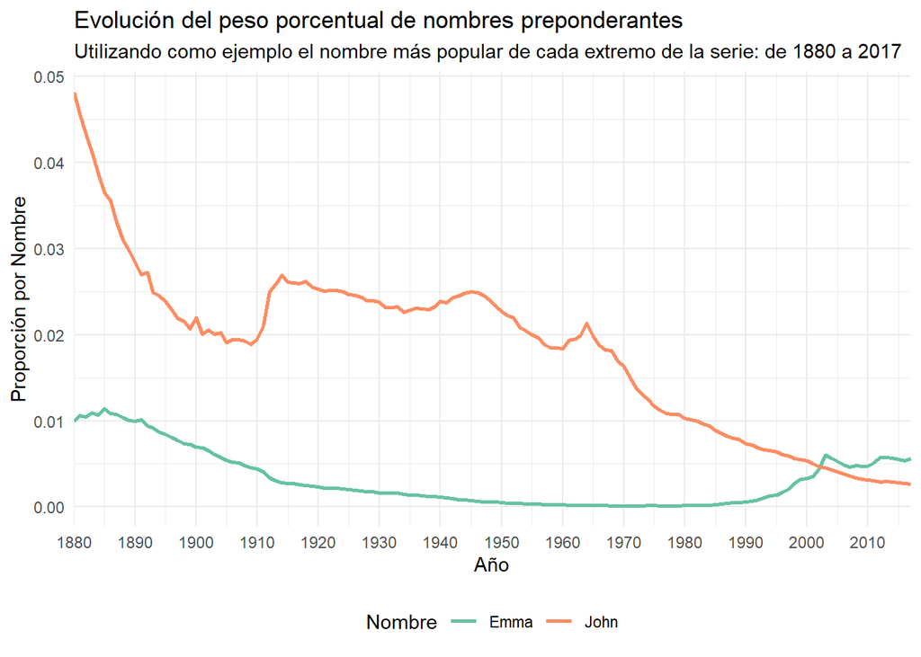

El nombre más popular del primer año de la serie fue John con un peso porcentual de 0.0481477, a su vez el nombre más popular en el último año de la serie fue Emma con un peso porcentual de 0.0055697.

### Pregunta 2

```r
respuesta_2 <-
              dbGetQuery(con,
                         " with cantidad_Nombre as (

                              select
                                 year
                                ,count(distinct name) as Dist_Name_Nu
                              from #Baby_Names
                              group by year

                              )
                           select
                             year
                            ,Dist_Name_Nu
                            ,avg(Dist_Name_Nu) over(order by year rows between 5 preceding and 5 following) as Promedio_Decada
                           from cantidad_Nombre; "

                        )
```

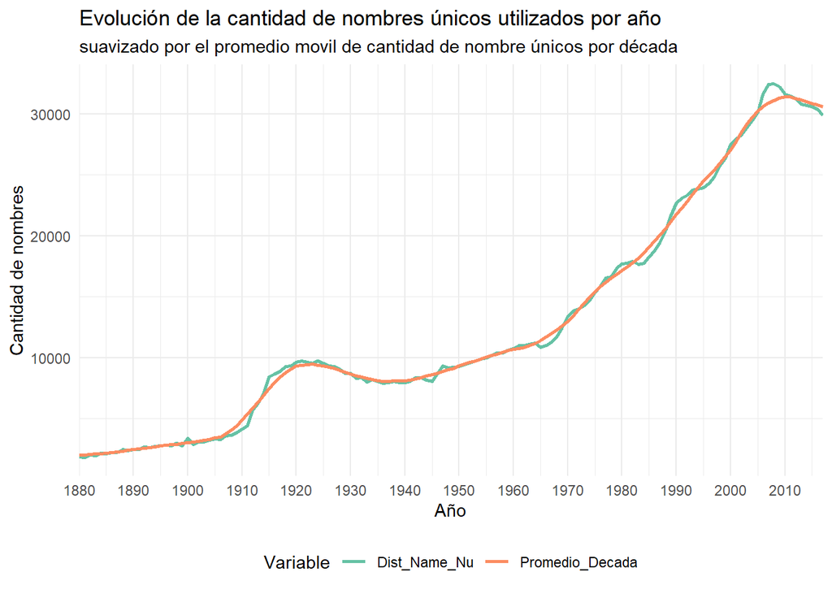

La cantidad de nombres únicos en el año 1880 fue de 1889.En comparación, en el año 2017 fueron 29910,lo que implica un aumento del 1483.38 %.

### Pregunta 3

```r
respuesta_3 <-
  dbGetQuery(con,
                  " with t1 as (

                       select
                         year
                         ,name
                         ,sum(case when sex = 'F' then n else 0 end) as Femenino
                         ,sum(case when sex = 'M' then n else 0 end) as Masculino
                         ,sum(n) as Total
                       from #Baby_Names
                       group by year,name

                     ),
                     tipo_de_nombres as (

                      select
                          year
                         ,case when Femenino = Total  then 'Femenino'
                               when Masculino = Total then 'Masculino'
                               else 'Mixto' end as Tipo_nombre
                         ,count(*) as n
                       from t1
                       group by year,
                                case when Femenino = Total  then 'Femenino'
                                     when Masculino = Total then 'Masculino'
                                else 'Mixto' end

                     ),
                     nombre_unicos as (

                         select
                            year
                           ,count(distinct name) as dist_name_Nu
                         from #Baby_Names
                         group by year
                     )
                     select
                         tn.year
                        ,tn.Tipo_nombre
                        ,tn.n * 1.0 / nu.dist_name_Nu as prop
                     from tipo_de_nombres as tn
                     inner join nombre_unicos as nu
                     on nu.year = tn.year; "

  )
```

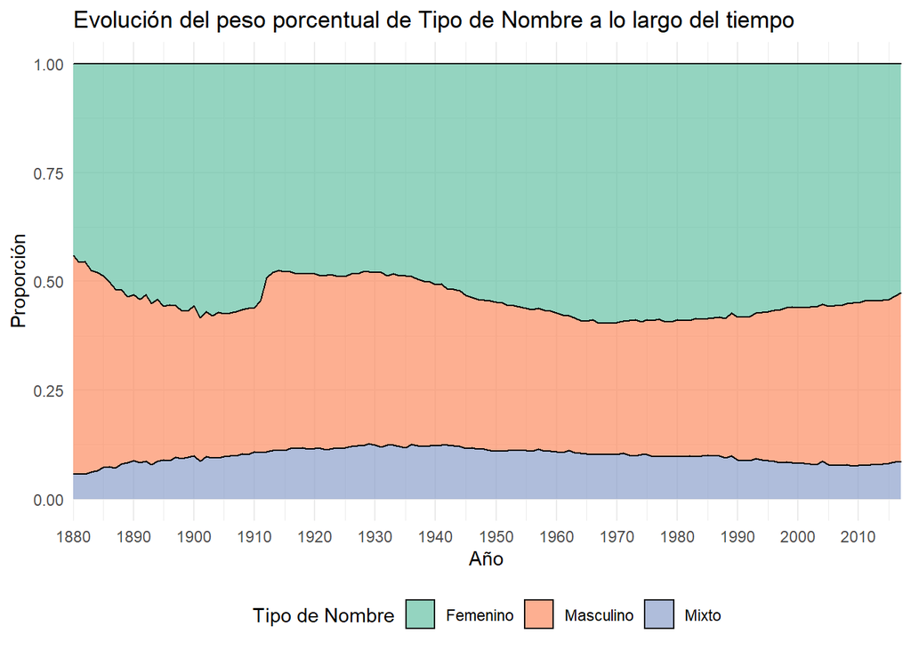

Los nombres de utilización mixta tienen un peso porcentual promedio a lo largo de la serie de 0.0996102, con su pico en el año 1929 con un peso de 0.1270807. En el último año tuverion un peso de 0.0855567.